# Data Analysis with R - Prosper Loan

After a close examination of my previous calculations on profit or loss, I noticed that the profit or loss percentage calculation does not consider the time value of money. Since loan payment is made monthly, the lender could have reinvested that money to generate higher yield. For finished loans that are paid on time, my calculation of profit or loss percentage per year is often lower than lender yield.

Thus, I’ve added another new variable to measure the return on Prosper loan. This new metric discount the money lender receives per month (borrower’s payment - Prosper fees) by the estimated number of loan payments to show the real rate of return for the annuity.

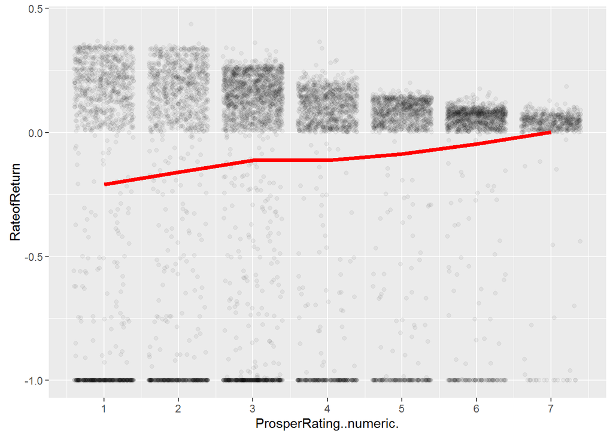

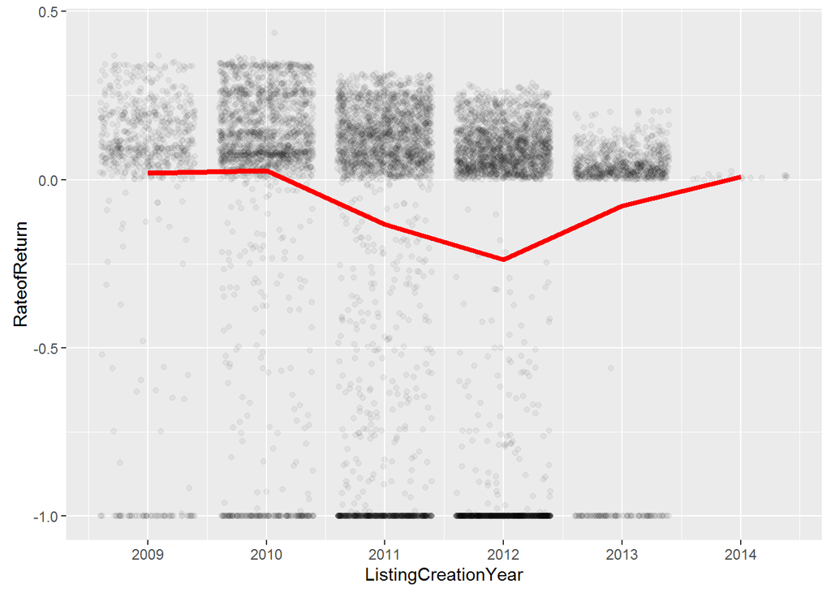

The result is not much different with the new Rate of Return. While Prosper’s mean estimated rate of return is positive, the actual mean Rate of Return is close to 0 or below 0. To dig deeper into this difference, I’ve compared the Rate of Return, Lender’s Yield, and Prosper’s estimated rate of return for different loan status.

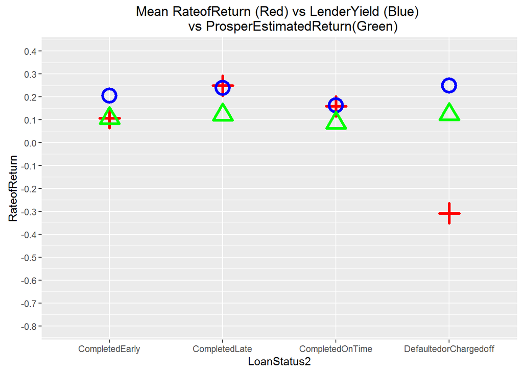

For loans that complete on time (number of payments = Term), the mean Rate of Return (red) is the same as the mean Lender’s Yield (blue). The Prosper’s mean Estimated of Return (green) is lower since it includes an estimated loss (which does not apply in this case since loans are paid in full and on time).

For loans that complete late (number of payments > Term), the mean Rate of Return (red) is slightly higher than the mean Lender’s Yield (blue) since the lender gets some extra interest on the loan.

For loans that complete early (number of payments < Term), the mean Rate of Return (red) is lower than the mean Lender’s Yield (blue) since the borrower saves on interest fee by paying off the loan earlier.

For Defaulted or Chargedoff loans, the mean Rate of Return (red) is significantly lower than the mean Lender’s Yield (blue) and the Prosper’s mean Estimated of Return (green). This major difference explains why the Rate of Return metric often shows poor return while Prosper’s estimated Returns are always positive.

Since Prosper’s Estimated Return is not a reliable measurement of return on Prosper loans, the section below will use Rate of Return as the principle measurement of loan return.

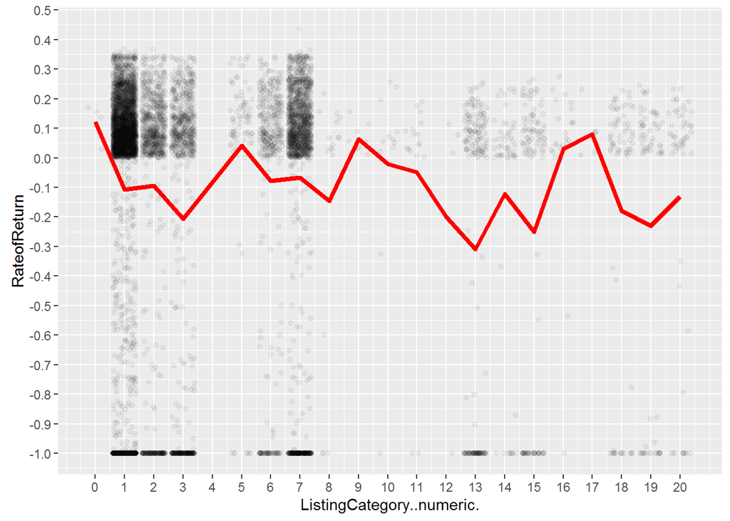

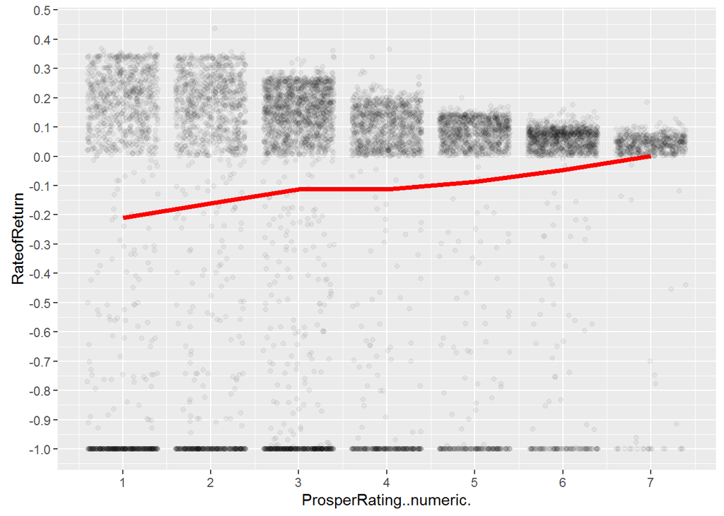

```
##
##  Pearson's product-moment correlation
##
## data:  FinishedLoan$RateofReturn and FinishedLoan$ProsperScore
## t = 15.959, df = 8754, p-value < 2.2e-16
## alternative hypothesis: true correlation is not equal to 0
## 95 percent confidence interval:
##  0.1477147 0.1884233
## sample estimates:
##       cor
## 0.1681407
```

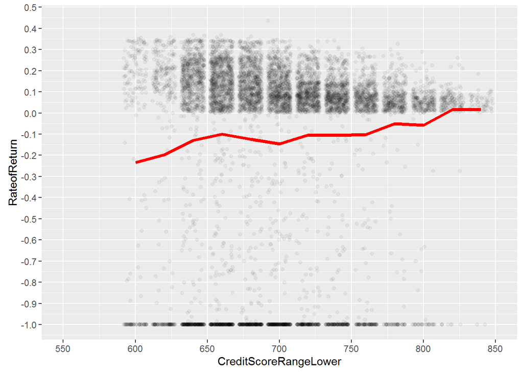

```
##
##  Pearson's product-moment correlation
##
## data:  FinishedLoan$RateofReturn and FinishedLoan$CreditScoreRangeLower
## t = 6.5423, df = 8754, p-value = 6.399e-11
## alternative hypothesis: true correlation is not equal to 0
## 95 percent confidence interval:
##  0.04887859 0.09056733
## sample estimates:
##        cor
## 0.06975342
```

The positive relationship between Rate of Return and Prosper Score is the opposite of the negative relationship between Prosper Estimated Return and Prosper Score. As Prosper Score goes up, Rate of Return increases. There is a weak positive correlation between these 2 variables. Similarly, Rate of Return is also positively correlated with Credit Score.

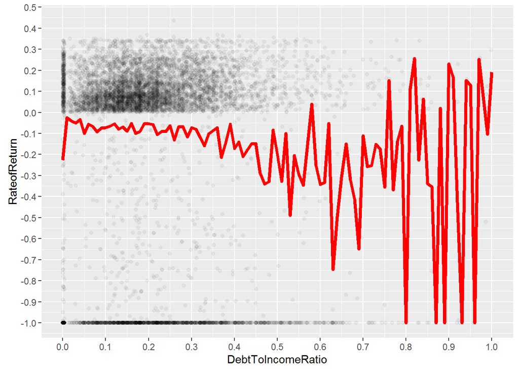

```
##
##  Pearson's product-moment correlation
##
## data:  FinishedLoan$DebtToIncomeRatio and FinishedLoan$RateofReturn
## t = -2.8203, df = 8754, p-value = 0.004808
## alternative hypothesis: true correlation is not equal to 0
## 95 percent confidence interval:
##  -0.051043905 -0.009189437
## sample estimates:
##         cor
## -0.03012988
```

Debt to income ratio does not seem to a good predictor of Rate of Return.

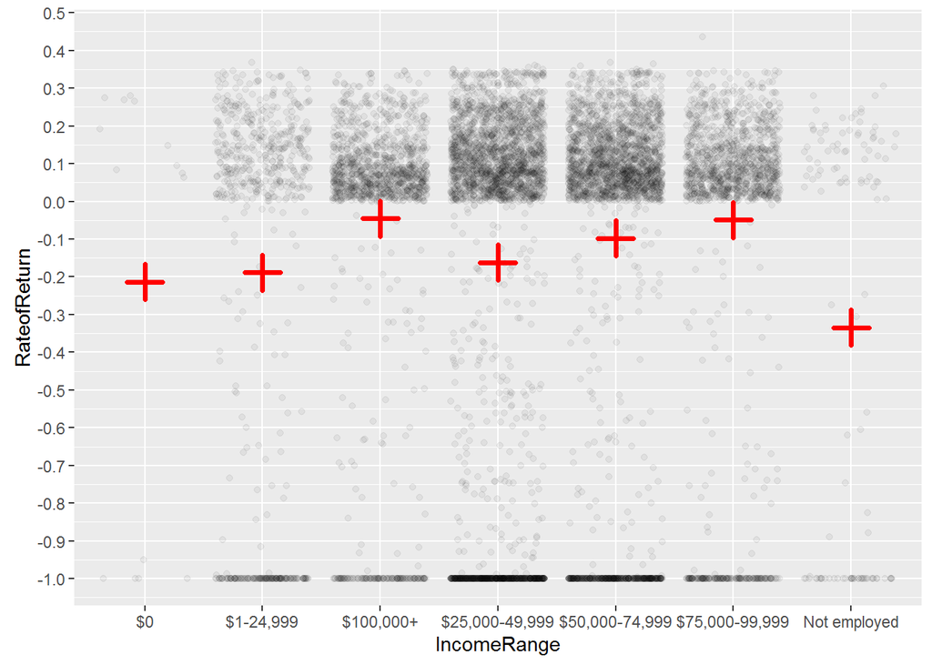

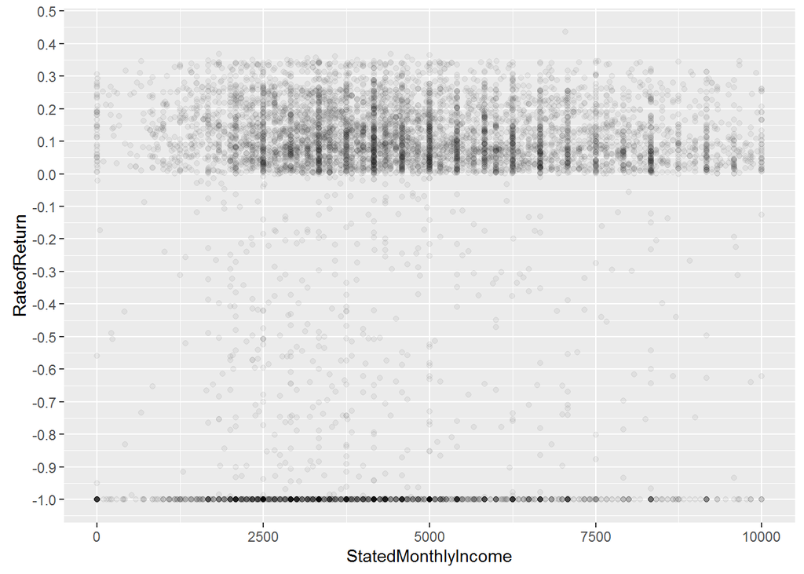

```
##
##  Pearson's product-moment correlation
##
## data:  FinishedLoan$RateofReturn and FinishedLoan$StatedMonthlyIncome
## t = 8.6265, df = 8754, p-value < 2.2e-16
## alternative hypothesis: true correlation is not equal to 0
## 95 percent confidence interval:
##  0.07100128 0.11254079
## sample estimates:
##        cor
## 0.09181098
```

Loans from borrowers with income range of 25,000 and above tend to have higher rate of return. Stated monthly income vs Rate of Return is too noisy to interpret. As discussed earlier, this variable contains many unreasonably high figures and may not be reliable.

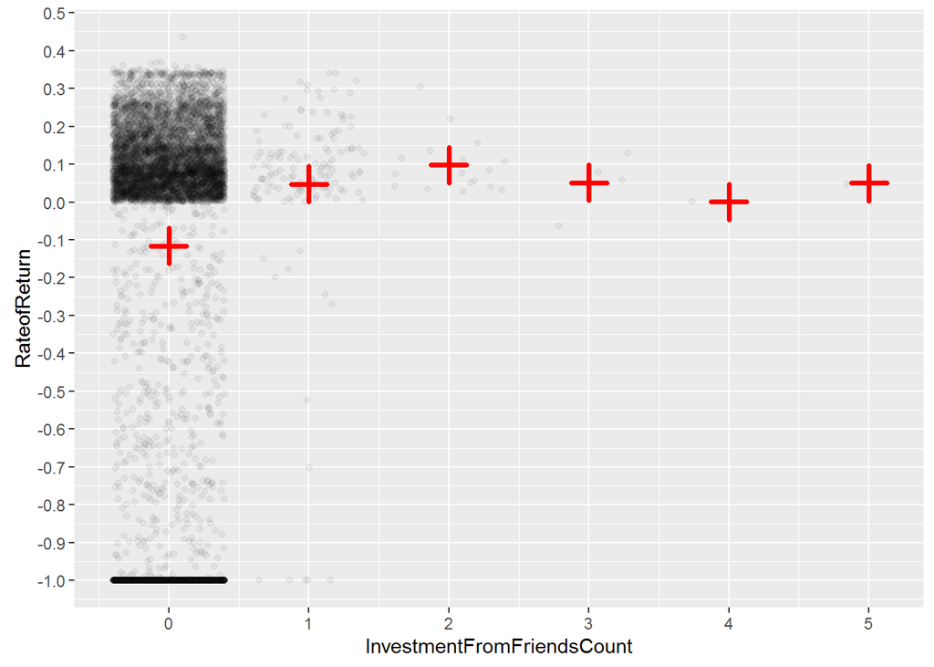

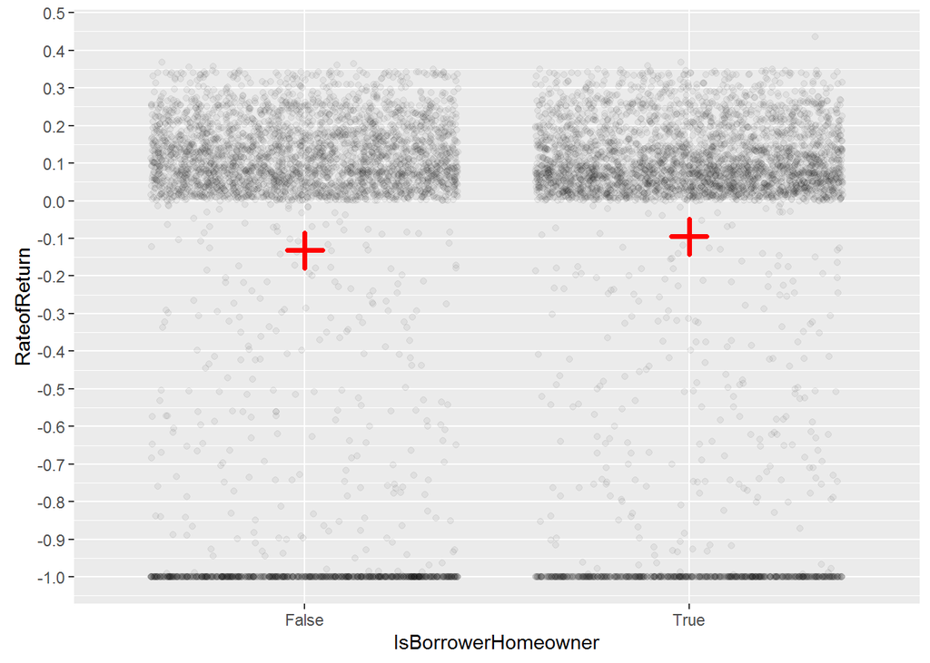

On average, loans with at least 1 friend investor have higher rate of return. However, these loans are few. Homeownership doesn’t seem to have any effect on rate of return.

# Bivariate Analysis

### Talk about some of the relationships you observed in this part of the investigation. How did the feature(s) of interest vary with other features in the dataset?

Prosper’s Estimated Return is not a good indicator of Prosper loans’ true rate of return since it tends to underestimate the effect of defaulted loans on lender’s return. This creates the illusion that higher risk loans are better investments due to their attractive higher APR. By my own calculation of Rate of Return, lenders are better off sticking to safer loan with good, verifiable credit score.

### Did you observe any interesting relationships between the other features (not the main feature(s) of interest)?

Listing category and Homeownership do not have a significant impact on Rate of Return. Surprisingly, debt to income ratio does not have any noticeable influence on Rate of Return. I had suspected that borrowers with lower debt to income ratio will be more likely to pay off their loans, thus, contributing to a higher Rate of Return.

### What was the strongest relationship you found?

Strongest relationship I found is between Borrower Rate and Prosper’s Estimated Return (cor = 0.7504967).

# Multivariate Plots Section

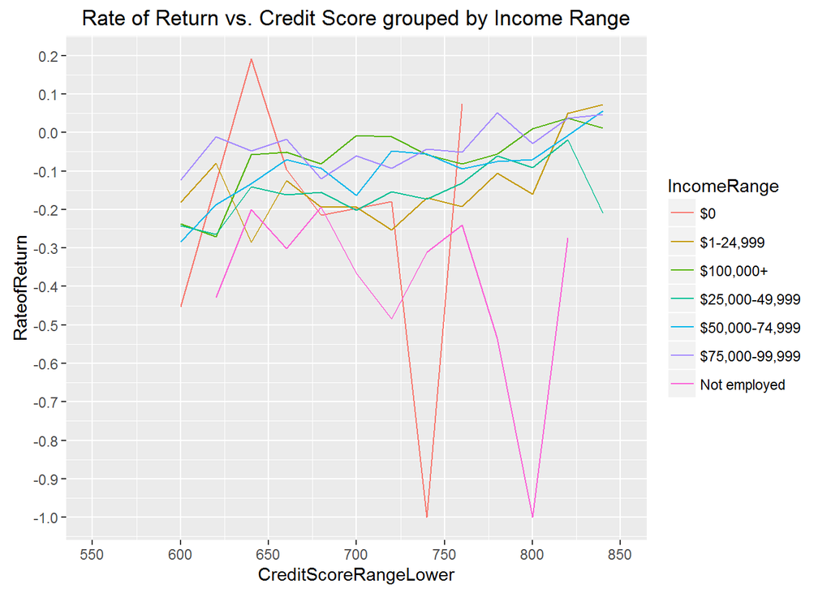

This plot tests whether the relationship between Rate of Return and Credit Score is different for certain income ranges. Loans in lower income Range (less than 25,000) and unemployed category tend to be unpredictable. For these groups, Credit Score alone is not a good predictor of Rate of Return.

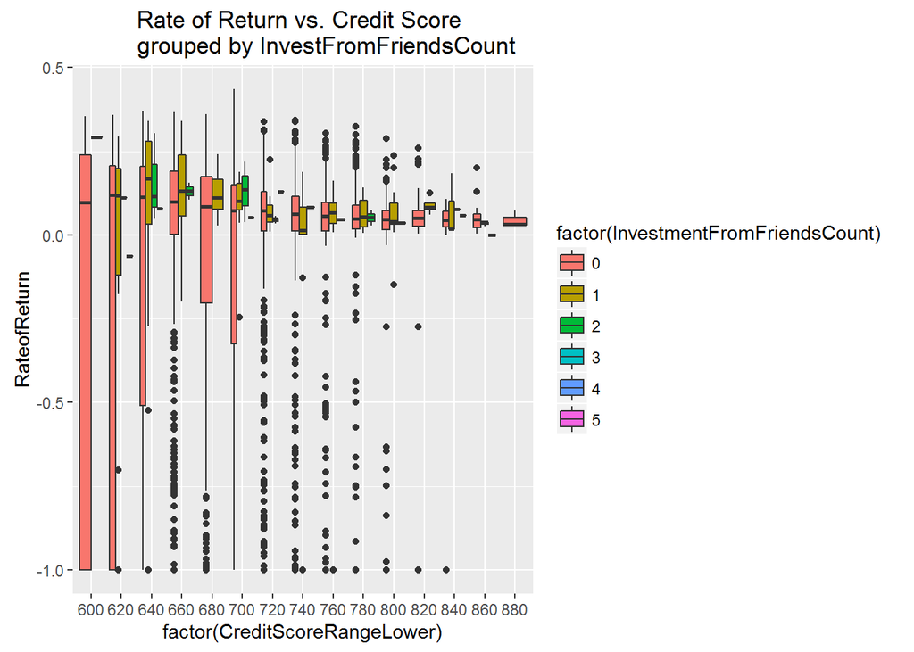

There are too few loans with Investment from Friends to make it a useful predictor of loan performance. However, in the rare occurrence that a loan is invested by friends, it tends to outperform similar loans with the same Credit Score.

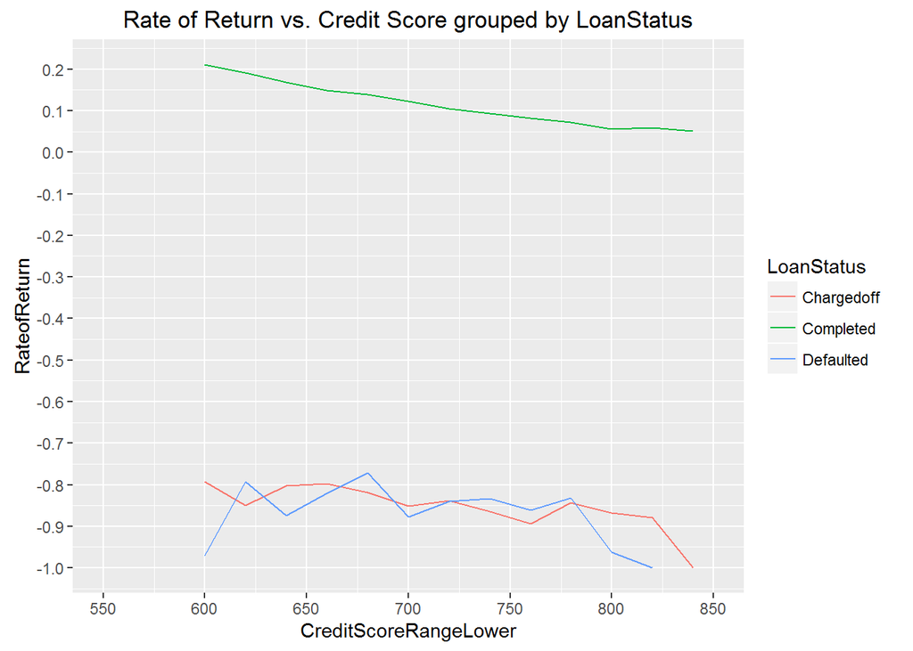

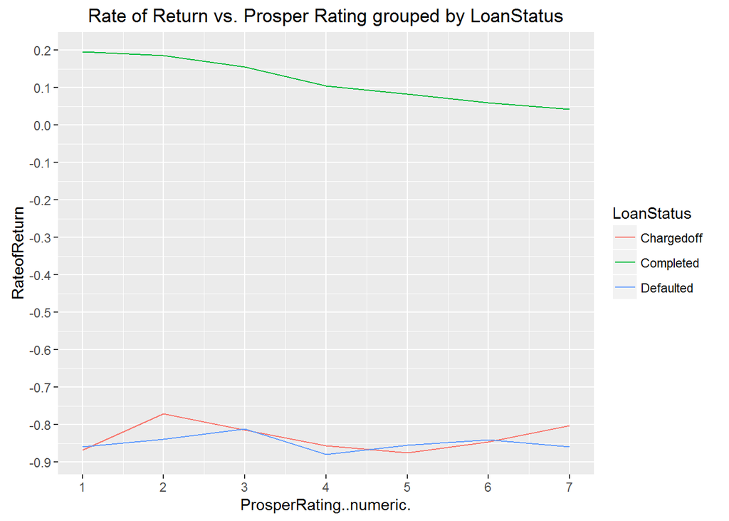

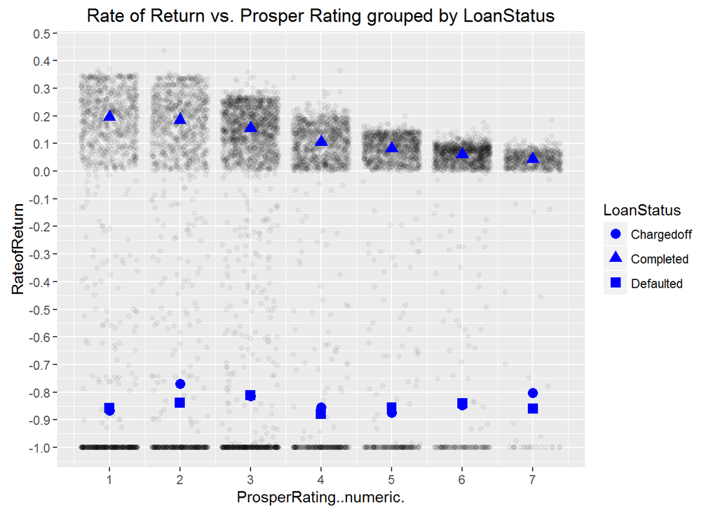

For these graphs, I explore if the relationship between loan status and rate of return can be different for different loan status. The initial result surprised me, though further analysis reaffirms my earlier observation. This will be discussed in more details in the section below.

# Multivariate Analysis

### Talk about some of the relationships you observed in this part of the investigation. Were there features that strengthened each other in terms of looking at your feature(s) of interest?

Loans with income range less than 25,000 tend to have lower Rate of Return. Beyond that, there is no significantly relationship between Rate of Return and higher income range. It seems that higher earners are just as likely as lower earners to default on a loans. Loans invested by friends tend to be safer. However, the number of loans with investment from friends are very small to be used to measure Rate of Return.

### Were there any interesting or surprising interactions between features?

The line graph of the mean Rate of Return by Prosper Rating confused me for a while. In this graph, I attempted to show the mean Rate of Return by Prosper Rating, separated by Loan Status. The mean Rate of Return for Completed loans shows a downward slope similar to the results of Prosper’s Estimated Return by Prosper Rating. As the mean Rates of Return for Defaulted and Chargedoff loans are relatively even between -0.8 and -0.9, I would expect that the combined mean Rate of Return for all loans would be a downward slope. In other words, the mean Rate of Return gets lower with higher Prosper Rating. However, an earlier graph of mean Rate of Return by Prosper Rating shows an upward line from -0.2 to 0 (i.e. mean Rate of Return improves with higher Prosper Rating).

To look at this issue at a different angle, I used a scatter plot with the same variables and parameters. While the mean Rates of Return for Completed, Defaulted, and Chargedoff loans follow the same trend lines as the line graph, it can be seen here that the number of Defaulted and Chargedoff loans is signifiantly higher for loans with lower Prosper Rating. Conversely, the number of Completed loans is lower for low Prosper Rating loans. This change in volume explains how the trend line of mean Rate of Return on Completed Loan can be downward while the overall mean Rate of Return can be upward.

### OPTIONAL: Did you create any models with your dataset? Discuss the strengths and limitations of your model.

No

# Final Plots and Summary

### Plot One

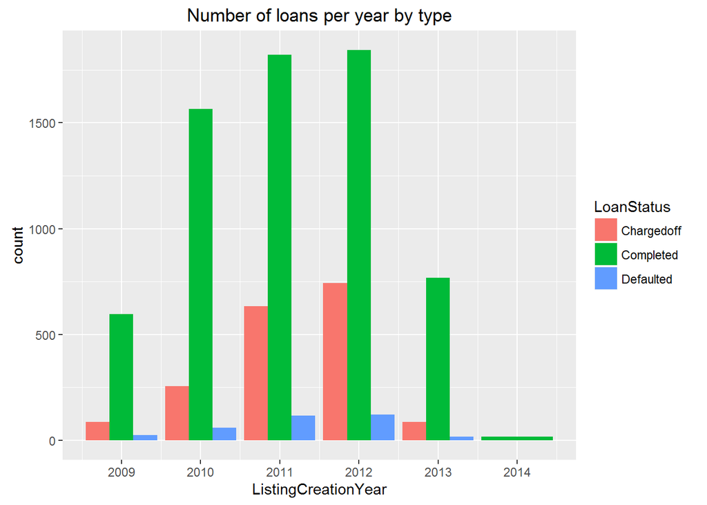

### Plot Two

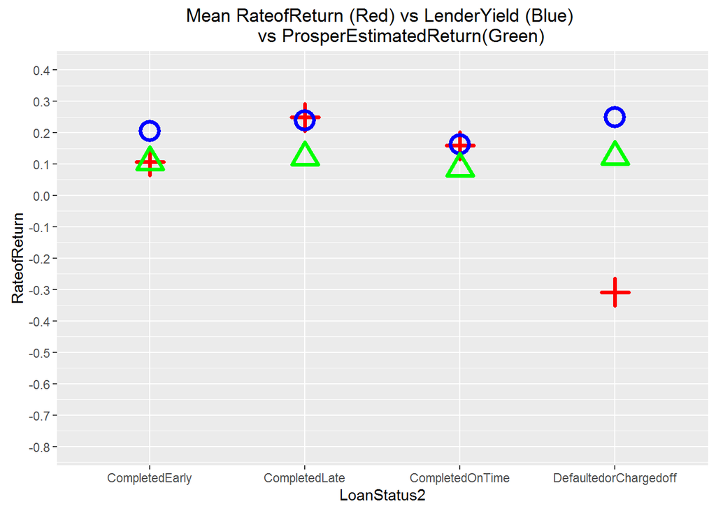

### Description Two

This comparison of mean Rate of Return vs. mean Lender Yield vs. mean Prosper’s Estimated Return shows why Prosper’s Estimated Return is not a reliable measurement of lender’s return on Prosper loans. It seems that Prosper’s own metric, at this point, has not accurately predicted default risk: Estimated Return is relatively unchanged for Defaulted loans and Completed loans. In addition, the graph shows that lender’s yield can be negatively affected by early payments. By paying off their loans early, the borrowers save on interest expense and cut into lender’s profit.

### Plot Three

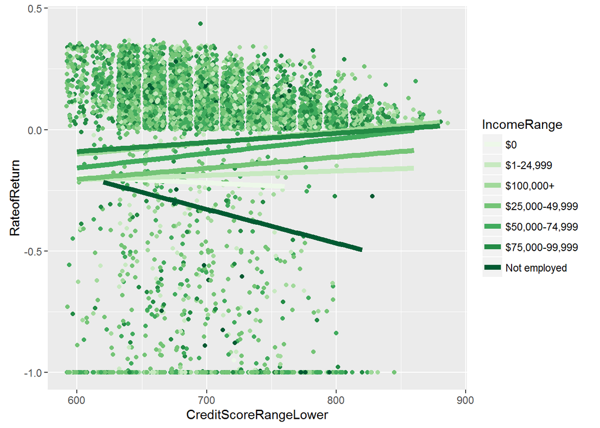

# Reflection

This has been the most time consuming Udacity project for me so far. The sheer volume and number of variables of this dataset make it a daunting task to just understand the data. The complexity of annuity valuation adds one big hurdle to my analysis. I can’t find any good guideline from Prosper or Lending Club on how to measure the profitability of its loan. In addition, the default risk is not very well communicated to lenders. As demonstrated by the class action lawsuit in 2008, Prosper lenders are evidently unhappy with their return on investment. In order for a normal investor to get involved in consumer loan, an area that has been exclusively served by bank and qualified financial investor, there must be more guideline and transparency to properly communicate and measure the loan’s risk and profitability. It is understandable why the SEC has intervened and classified Prosper Loan as securities that require proper monitoring and regulation.

There are several limitations to my analysis that may affect its result. First of all, since Prosper Score is only available in 2009 and most loans have a 3 year term, the FinishedLoan dataset that I investigated is significantly smaller than the original dataset. Secondly, Prosper’s metrics to help guide lenders with their investment were only introduced in 2009. It is possible that these metrics have improved over the year but the effect is not yet shown as these loans are still outstanding and thus, excluded from the FinishedLoan dataset. For this project, I have not investigated if Prosper metrics have changed over the years. Thirdly, since Prosper does not disclose the formula for its metrics, it is possible that my metrics and theirs may not be commensurable.